# Data Handling: Import, Cleaning and Visualisation

Lecture 10: Basic Data Analytics

Prof. Dr. Ulrich Matter

# Data Analysis with R

## Merging (Joining) datasets

- Combine data of two datasets in one dataset.
- Needed: Unique identifiers for observations (‘keys’).

Consider the following two data sets.

```r
# load packages
library(tidyverse)

# initiate data frame on persons personal spending
df_c <- data.frame(id = c(1:3,1:3),
                   money_spent= c(1000, 2000, 6000, 1500, 3000, 5500),
                   currency = c("CHF", "CHF", "USD", "EUR", "CHF", "USD"),
                   year=c(2017,2017,2017,2018,2018,2018))
df_c
```

```
##   id money_spent currency year
## 1  1        1000      CHF 2017
## 2  2        2000      CHF 2017
## 3  3        6000      USD 2017
## 4  1        1500      EUR 2018
## 5  2        3000      CHF 2018
## 6  3        5500      USD 2018
```

```r
# initiate data frame on persons' characteristics
df_p <- data.frame(id = 1:4,
                   first_name = c("Anna", "Betty", "Claire", "Diane"),
                   profession = c("Economist", "Data Scientist", "Data Scientist", "Economist"))
df_p
```

```
##   id first_name     profession
## 1  1       Anna      Economist
## 2  2      Betty Data Scientist
## 3  3     Claire Data Scientist
## 4  4      Diane      Economist
```

`df_c` contains information on person’s consumption spending, `df_p` information on these person’s personal characteristics. We can merge/join the two data frames via a unique person identifier in column `id`. There are four basic ways of joining the two datasets when not all of the observations are complete:

1. The *Inner Join*: only complete observations are kept in the resulting new data frame.

```r
df_merged <- merge(df_p, df_c, by="id")
df_merged
```

```
##   id first_name     profession money_spent currency year
## 1  1       Anna      Economist        1000      CHF 2017
## 2  1       Anna      Economist        1500      EUR 2018
## 3  2      Betty Data Scientist        2000      CHF 2017
## 4  2      Betty Data Scientist        3000      CHF 2018
## 5  3     Claire Data Scientist        6000      USD 2017
## 6  3     Claire Data Scientist        5500      USD 2018
```

2. The *Outer Join*: all observations are kept, missing values are indicated with `NA`s.

```r
df_merged <- merge(df_p, df_c, by="id", all=TRUE)
df_merged
```

```
##   id first_name     profession money_spent currency year
## 1  1       Anna      Economist        1000      CHF 2017
## 2  1       Anna      Economist        1500      EUR 2018
## 3  2      Betty Data Scientist        2000      CHF 2017
## 4  2      Betty Data Scientist        3000      CHF 2018
## 5  3     Claire Data Scientist        6000      USD 2017
## 6  3     Claire Data Scientist        5500      USD 2018
## 7  4      Diane      Economist          NA     <NA>   NA
```

3. The *Left Join*: all observations in the “left” data frame (the first argument; x) are kept, but not all in the “right” data frame (the second argument, y). Again, missing values are indicated with `NA`s.

```r
df_merged <- merge(df_p, df_c, by="id", all.x = TRUE, all.y = FALSE)
df_merged
```

```
##   id first_name     profession money_spent currency year
## 1  1       Anna      Economist        1000      CHF 2017
## 2  1       Anna      Economist        1500      EUR 2018
## 3  2      Betty Data Scientist        2000      CHF 2017
## 4  2      Betty Data Scientist        3000      CHF 2018
## 5  3     Claire Data Scientist        6000      USD 2017
## 6  3     Claire Data Scientist        5500      USD 2018
## 7  4      Diane      Economist          NA     <NA>   NA
```

```r
df_merged <- merge(df_p, df_c, by="id", all.x = FALSE, all.y = TRUE)
df_merged
```

```
##   id first_name     profession money_spent currency year
## 1  1       Anna      Economist        1000      CHF 2017
## 2  1       Anna      Economist        1500      EUR 2018
## 3  2      Betty Data Scientist        2000      CHF 2017
## 4  2      Betty Data Scientist        3000      CHF 2018
## 5  3     Claire Data Scientist        6000      USD 2017
## 6  3     Claire Data Scientist        5500      USD 2018
```

## Merging (joining) datasets: the concept

[figure not shown]

Different approaches to merging two datasets: left join, right join, inner join, outer join.

## Merging (joining) datasets in R

Overview by Wickham and Grolemund (2017):

| dplyr (tidyverse) | base::merge |
| --- | --- |
| `inner_join(x, y)` | `merge(x, y)` |
| `left_join(x, y)` | `merge(x, y, all.x = TRUE)` |
| `right_join(x, y)` | `merge(x, y, all.y = TRUE)`, |
| `full_join(x, y)` | `merge(x, y, all.x = TRUE, all.y = TRUE)` |

# Data Summaries: Selecting, Filtering, and Mutating

## Data summaries

- First step of analysis.
- Get overview over dataset.
- Show key aspects of data.
  - Inform your own statistical analysis.
  - Inform audience (helps understand advanced analytics parts)

Typical tasks related to the last preparatory steps for analytics or the computation of data summaries are:

- *Select* subset of variables (e.g., for comparisons).
- *Filter* the dataset (some observations not needed in *this* analysis).
- *Mutate* the dataset: additional values needed

With their corresponding functions in `tidyverse`:

- `select()`
- `filter()`
- `mutate()`

## Examples: selection, filtering, mutating

`summary()` computes a few key summary statistics for each variable:

```r
# summary statistics for each variable
summary(df_merged)
```

```
##        id        first_name         profession         money_spent     currency
##  Min.   :1.00   Length:6           Length:6           Min.   :1000   Length:6
##  1st Qu.:1.25   Class :character   Class :character   1st Qu.:1625   Class :character
##  Median :2.00   Mode  :character   Mode  :character   Median :2500   Mode  :character
##  Mean   :2.00                                         Mean   :3167
##  3rd Qu.:2.75                                         3rd Qu.:4875
##  Max.   :3.00                                         Max.   :6000
##       year
##  Min.   :2017
##  1st Qu.:2017
##  Median :2018
##  Mean   :2018
##  3rd Qu.:2018
##  Max.   :2018
```

`table()` computes the cross-tabulation of categorical variables:

```r
# cross-tabulation (categorical variables)
table(df_merged$year)
```

```
##
## 2017 2018
##    3    3
```

```r
table(df_merged$year, df_merged$profession)
```

```
##
##        Data Scientist Economist
##   2017              2         1
##   2018              2         1
```

Hint: this is also very useful to detect potential inconsistencies in the coding of categorical variables.

Select a subset of columns/variables via `select()`:

```r
df_selection <- select(df_merged, id, year, money_spent, currency)
df_selection
```

```
##   id year money_spent currency
## 1  1 2017        1000      CHF
## 2  1 2018        1500      EUR
## 3  2 2017        2000      CHF
## 4  2 2018        3000      CHF
## 5  3 2017        6000      USD
## 6  3 2018        5500      USD
```

Filter for a subset of rows/observations via `filter()`:

```r
# one filtering condition
filter(df_selection, year == 2018)
```

```
##   id year money_spent currency
## 1  1 2018        1500      EUR
## 2  2 2018        3000      CHF
## 3  3 2018        5500      USD
```

```r
# several filtering conditions
filter(df_selection, year == 2018, money_spent < 5000, currency=="EUR")
```

```
##   id year money_spent currency
## 1  1 2018        1500      EUR
```

Add/change variables (columns) via `mutate()`. In this example, we first create an additional data frame then add the data from this new data frame via `merge()` to the main data frame, and finally create a new version of the main data frame with a new column via `mutate()`.

```r
# initiate an exchange-rate data frame
exchange_rates <- data.frame(exchange_rate= c(0.9, 1, 1.2),
                             currency=c("USD", "CHF", "EUR"), stringsAsFactors = FALSE)
# join the exchange-rate with the main dataset
df_selection <- merge(df_selection, exchange_rates, by="currency")

# add the new variable with money spent in CHF
df_mutated <- mutate(df_selection, money_spent_chf = money_spent * exchange_rate)
df_mutated
```

```
##   currency id year money_spent exchange_rate money_spent_chf
## 1      CHF  1 2017        1000           1.0            1000
## 2      CHF  2 2017        2000           1.0            2000
## 3      CHF  2 2018        3000           1.0            3000
## 4      EUR  1 2018        1500           1.2            1800
## 5      USD  3 2017        6000           0.9            5400
## 6      USD  3 2018        5500           0.9            4950
```

## Summary statistics and aggregation

# Aggregate Statistics

- Overview of key characteristics of main variables used in analysis.
- Key characteristics:
  - mean
  - standard deviation
  - No. of observations
  - etc.

In R, we can typically rely on two types of functions that help us compute descriptive statistics for a dataset.

1. Functions to compute statistics (`mean()`, `median()`).
2. Functions to *apply* the statistics function to one or several columns in a tidy dataset. Either for all values in a column, or separately by groups of observations (observation categories, e.g. by gender, year, location, etc.)

For example, `summarise()` and `group_by()` provided in `tidyverse`, as well as `sapply()`, `apply()`, `lapply()`, etc. provided in `base`-R.

Use `summarise()` to create a simple descriptive statistics table:

```r
# generate a simple descriptive statistics table
summarise(df_mutated,
          mean = mean(money_spent_chf),
          standard_deviation = sd(money_spent_chf),
          median = median(money_spent_chf),
          N = n())
```

```
##   mean standard_deviation median N
## 1 3025           1788.785   2500 6
```

In case the descriptive statistics should be computed for a set of sub-groups, combine `summarise()` with `group_by()` as follows:

```r
# summarize by groups of observations ("split-apply-combine")
# split into year-groups
by_year <- group_by(df_mutated, year)
# apply statistics functions, and combine results in one table
summarise(by_year,
          mean = mean(money_spent_chf),
          standard_deviation = sd(money_spent_chf),
          median = median(money_spent_chf),
          N = n())
```

```
## # A tibble: 2 × 5
##    year  mean standard_deviation median     N
##   <dbl> <dbl>              <dbl>  <dbl> <int>
## 1  2017  2800              2307.   2000     3
## 2  2018  3250              1590.   3000     3
```

Appart from the `tidyverse`-approach via `summarise()`, basic R provides a set of helpful `apply`-type functions to summarize datasets in a more flexible way. For example, we can use `sapply()` to compute the mean of each column in a data frame:

```r
# apply-type functions for data summaries

# load data
data("swiss")

# compute the mean for each variable (column)
sapply(swiss, mean)
```

```
##        Fertility      Agriculture      Examination        Education         Catholic
##         70.14255         50.65957         16.48936         10.97872         41.14383
## Infant.Mortality
##         19.94255
```

# Data Analytics: a primer in linear regression/OLS

## Some vocabulary

- *Dependent variable*: $y_i$.
- *Explanatory variable*: $x_i$.
- “All the rest”: $u_{i}$ (the *‘residuals’* or the ‘error term’).

A simple linear model: $y_{i}= \alpha + \beta x_{i} + u_{i}$.

- $\alpha$ is the intercept. By adding an intercept to the linear model, we acknowledge that the value of $y_i$ might not be 0 when $x_i$ is 0.
- $\beta x_{i}$ is the slope coefficient. It’s value tells us by how much $y_i$ changes if $x_i$ is increased by one unit.

## Illustration with pseudo-data

First, we define the key parameters for the simulation. We choose the actual values of $\alpha$ and $\beta$, and set the number of observations $N$.

```r
alpha <- 30
beta <- 0.9
N <- 1000
```

```r
x <- runif(N, 0, 50)
```

```r
# draw the random errors (all the other factors also affecting y)
epsilon <- rnorm(N, sd=10)
# compute the dependent variable values
y <- alpha + beta*x + epsilon
```

## Illustration with pseudo-data

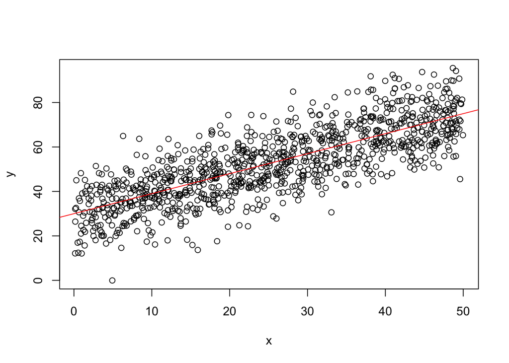

```r
plot(x,y)
abline(a = alpha, b=beta, col="red")
```

## Illustration with pseudo data: “averaging”

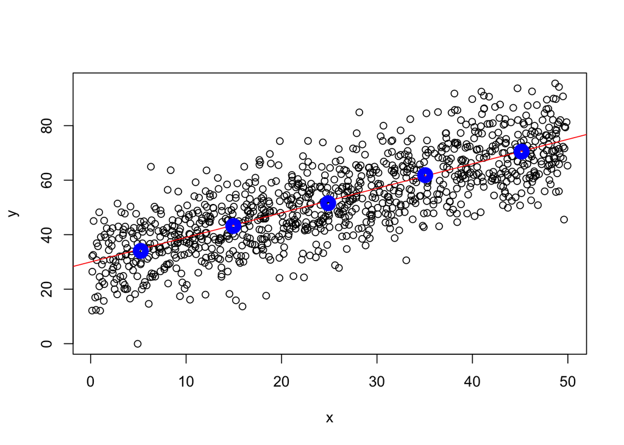

```r
# compute average y per x intervals
lower <- c(0,10,20,30,40)
upper <- c(lower[-1], 50)
n_intervals <- length(lower)
y_bars <- list()
length(y_bars) <- n_intervals
x_bars <- list()
length(x_bars) <- n_intervals
for (i in 1:n_intervals){
  y_bars[i] <- mean(y[lower[i] <= x & x < upper[i]])
  x_bars[i] <- mean(x[lower[i] <= x & x < upper[i]])

}
y_bars <- unlist(y_bars)
x_bars <- unlist(x_bars)

# add to plot
plot(x,y)
abline(a = alpha, b=beta, col="red")
points(x_bars, y_bars, col="blue", lwd=10)
```

## Parameter estimation: “average out the $u$”

Clearly, the average values are much closer to the real values. That is, we can ‘average out’ the $u$ in order to get a good estimate for the effect of $x$ on $y$ (to get an estimate of $\beta$). With this understanding, we can now formalize how to compute $\beta$ (or, to be more precise, an estimate of it: $\hat{\beta}$). For simplicity, we take $\alpha=30$ as given.

In a first step we take the averages of both sides of our initial regression equation:

$\frac{1}{N}\sum{y_i}=\frac{1}{N}\sum{(30 + \beta x_{i} + u_{i})}$,

rearranging and using the common ‘bar’-notation for means, we get

$\bar{y}=30+\beta\bar{x} + \bar{u}$,

and solving for $\beta$ and some rearranging then yields

$\beta=\frac{\bar{y}-30-\bar{u}}{\bar{x}}$.

While the elements in $\bar{u}$ are unobservable, we can use the rest to compute an estimate of $\beta$:

$\hat{\beta}=\frac{\bar{y}-30}{\bar{x}}$.

```r
(mean(y) -30)/mean(x)
```

```
## [1] 0.886768
```

## Data analytics perspective and estimation: data

```r
# load the data
data(swiss)
# look at the description
?swiss
```

## Data analytics perspective and estimation: research question

- Do more years of schooling improve educational outcomes?
- Approximate educational attainment with the variable `Education` and educational outcomes with the variable `Examination`.
- Make use of the simple linear model to investigate whether more schooling improves educational outcomes (on average)?

## Model specification

Our very simple model of how the average level of educational attainment in a district $i$ is related to the average performance in the standardized test is defined as follows:

$Examination_{i}= \alpha + \beta Education_{i}$.

Intuitively we would expect that $\beta$ is positive, indicating that a higher share of draftees with more years of schooling results in a higher share of draftees who reach the highest examination mark.

To formally acknowledge that other factors might also play a role, we extend our model with the term $u_{i}$. For the moment, we thus subsume all other potentially relevant factors in that term:

$Examination_{i}= \alpha + \beta Education_{i} + u_{i}$.

## Scatter-plot of the raw data

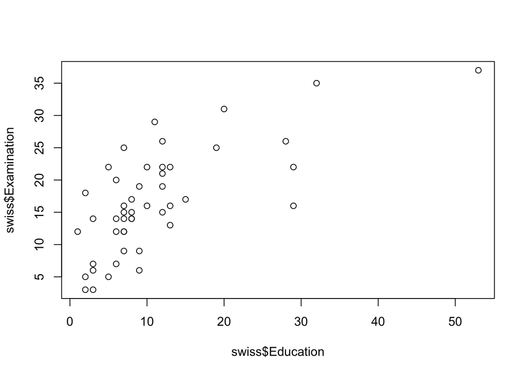

```r
plot(swiss$Education, swiss$Examination)
```

## Derivation and implementation of OLS estimator

From the model equation we easily see that these ‘differences’ between the predicted and the actual values of $y$ are the remaining unexplained component $u$:

$y_{i}-\hat{\alpha}-\hat{\beta} x_i=u_i$.

Hence, we want to minimize the *sum of squared residuals (SSR)*: $\sum{u_i^2}=\sum{(y_{i}-\hat{\alpha}-\hat{\beta} x_i)^2}$. Using calculus, we define the two first order conditions:

$$\frac{\partial SSR}{\partial
\hat{\alpha}}=\sum{-2(y_{i}-\hat{\alpha}-\hat{\beta}
x_i)}=0$$

$$\frac{\partial SSR}{\partial
\hat{\beta}}=\sum{-2x_i(y_{i}-\hat{\alpha}-\hat{\beta}
x_i)}=0$$

## Derivation and implementation of OLS estimator

The first condition is relatively easily solved by getting rid of the $-2$ and considering that $\sum{y_i}=N\bar{y}$: $\hat{\alpha}=\bar{y}-\hat{\beta}\bar{x}$.

## Derivation and implementation of OLS estimator

By plugging the solution for $\hat{\alpha}$ into the first order condition regarding $\hat{\beta}$ and again considering that $\sum{y_i}=N\bar{y}$, we get the solution for the slope coefficient estimator:

$\frac{\sum{x_{i}y_{i}}-N\bar{y}\bar{x}}{\sum{x_i^2}-N\bar{x}^2}$.

## OLS estimator in R!

```r
# implement the simple OLS estimator
# verify implementation with simulated data from above
# my_ols(y,x)
# should be very close to alpha=30 and beta=0.9
my_ols <-
  function(y,x) {
    N <- length(y)
    betahat <- (sum(y*x) - N*mean(x)*mean(y)) / (sum(x^2)-N*mean(x)^2)
    alphahat <- mean(y)-betahat*mean(x)

    return(list(alpha=alphahat,beta=betahat))
  }

# estimate effect of Education on Examination
estimates <- my_ols(swiss$Examination, swiss$Education)
estimates
```

```
## $alpha
## [1] 10.12748
##
## $beta
## [1] 0.5794737
```

We can visually verify how well our own OLS-estimator works as follows:

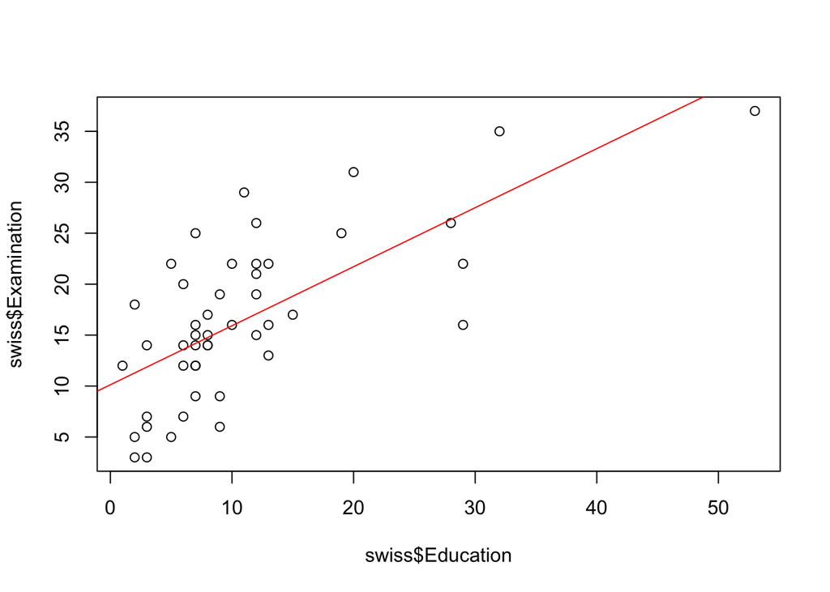

```r
plot(swiss$Education, swiss$Examination)
abline(estimates$alpha, estimates$beta, col="red")
```

## Regression toolbox in R

Of course, R already provides various functions to run regression analyses. The most commonly used function for simple linear regressions is `lm()`:

```r
estimates2 <- lm(Examination~Education, data=swiss)
estimates2
```

```
##
## Call:
## lm(formula = Examination ~ Education, data = swiss)
##
## Coefficients:
## (Intercept)    Education
##     10.1275       0.5795
```

With one additional line of code we can compute all the common statistics about the regression estimation:

```r
summary(estimates2)
```

```
##
## Call:
## lm(formula = Examination ~ Education, data = swiss)
##
## Residuals:
##      Min       1Q   Median       3Q      Max
## -10.9322  -4.7633  -0.1838   3.8907  12.4983
##
## Coefficients:
##             Estimate Std. Error t value Pr(>|t|)
## (Intercept) 10.12748    1.28589   7.876 5.23e-10 ***
## Education    0.57947    0.08852   6.546 4.81e-08 ***
## ---
## Signif. codes:  0 '***' 0.001 '**' 0.01 '*' 0.05 '.' 0.1 ' ' 1
##
## Residual standard error: 5.773 on 45 degrees of freedom
## Multiple R-squared:  0.4878, Adjusted R-squared:  0.4764
## F-statistic: 42.85 on 1 and 45 DF,  p-value: 4.811e-08
```